# 两个目标

## 1.什么样的用户购买力最强，哪些产品卖的最好

## 2.预测用户购买力

```python
import pandas as pd#导入相关包
import numpy as np
import random as rnd
from sklearn.preprocessing import LabelEncoder
from sklearn import linear_model
from sklearn.model_selection import cross_val_score, cross_val_predict

# visualization
import seaborn as sns
import matplotlib.pyplot as plt
```

```python
df=pd.read_csv(r'E:\dataanalyseprac\BlackFriday.csv')
```

```python
df.info()
```

```
<class 'pandas.core.frame.DataFrame'>
RangeIndex: 537577 entries, 0 to 537576
Data columns (total 12 columns):
User_ID                       537577 non-null int64
Product_ID                    537577 non-null object
Gender                        537577 non-null object
Age                           537577 non-null object
Occupation                    537577 non-null int64
City_Category                 537577 non-null object
Stay_In_Current_City_Years    537577 non-null object
Marital_Status                537577 non-null int64
Product_Category_1            537577 non-null int64
Product_Category_2            370591 non-null float64
Product_Category_3            164278 non-null float64
Purchase                      537577 non-null int64
dtypes: float64(2), int64(5), object(5)
memory usage: 49.2+ MB
```

```python
df.head(10)
```

|  | User_ID | Product_ID | Gender | Age | Occupation | City_Category | Stay_In_Current_City_Years | Marital_Status | Product_Category_1 | Product_Category_2 | Product_Category_3 | Purchase |
| --- | --- | --- | --- | --- | --- | --- | --- | --- | --- | --- | --- | --- |
| 0 | 1000001 | P00069042 | F | 0-17 | 10 | A | 2 | 0 | 3 | NaN | NaN | 8370 |
| 1 | 1000001 | P00248942 | F | 0-17 | 10 | A | 2 | 0 | 1 | 6.0 | 14.0 | 15200 |
| 2 | 1000001 | P00087842 | F | 0-17 | 10 | A | 2 | 0 | 12 | NaN | NaN | 1422 |
| 3 | 1000001 | P00085442 | F | 0-17 | 10 | A | 2 | 0 | 12 | 14.0 | NaN | 1057 |
| 4 | 1000002 | P00285442 | M | 55+ | 16 | C | 4+ | 0 | 8 | NaN | NaN | 7969 |
| 5 | 1000003 | P00193542 | M | 26-35 | 15 | A | 3 | 0 | 1 | 2.0 | NaN | 15227 |
| 6 | 1000004 | P00184942 | M | 46-50 | 7 | B | 2 | 1 | 1 | 8.0 | 17.0 | 19215 |
| 7 | 1000004 | P00346142 | M | 46-50 | 7 | B | 2 | 1 | 1 | 15.0 | NaN | 15854 |
| 8 | 1000004 | P0097242 | M | 46-50 | 7 | B | 2 | 1 | 1 | 16.0 | NaN | 15686 |
| 9 | 1000005 | P00274942 | M | 26-35 | 20 | A | 1 | 1 | 8 | NaN | NaN | 7871 |

```python
df.shape
```

```
(537577, 12)
```

```python
pd.isnull(df).sum() #or pd.isnull(df).any()
```

```
User_ID                            0
Product_ID                         0
Gender                             0
Age                                0
Occupation                         0
City_Category                      0
Stay_In_Current_City_Years         0
Marital_Status                     0
Product_Category_1                 0
Product_Category_2            166986
Product_Category_3            373299
Purchase                           0
dtype: int64
```

可以看出，产品分类2，3存在大量缺失值，而分类1无缺失值，三种分类存在一定重叠，因此考虑只保留分类1，去除2，3。 总体而言，这份数据的质量还是蛮好的

```python
df=df.drop(['Product_Category_2','Product_Category_3'],1)
df.head(20)
```

|  | User_ID | Product_ID | Gender | Age | Occupation | City_Category | Stay_In_Current_City_Years | Marital_Status | Product_Category_1 | Purchase |
| --- | --- | --- | --- | --- | --- | --- | --- | --- | --- | --- |
| 0 | 1000001 | P00069042 | F | 0-17 | 10 | A | 2 | 0 | 3 | 8370 |
| 1 | 1000001 | P00248942 | F | 0-17 | 10 | A | 2 | 0 | 1 | 15200 |
| 2 | 1000001 | P00087842 | F | 0-17 | 10 | A | 2 | 0 | 12 | 1422 |
| 3 | 1000001 | P00085442 | F | 0-17 | 10 | A | 2 | 0 | 12 | 1057 |
| 4 | 1000002 | P00285442 | M | 55+ | 16 | C | 4+ | 0 | 8 | 7969 |
| 5 | 1000003 | P00193542 | M | 26-35 | 15 | A | 3 | 0 | 1 | 15227 |
| 6 | 1000004 | P00184942 | M | 46-50 | 7 | B | 2 | 1 | 1 | 19215 |
| 7 | 1000004 | P00346142 | M | 46-50 | 7 | B | 2 | 1 | 1 | 15854 |
| 8 | 1000004 | P0097242 | M | 46-50 | 7 | B | 2 | 1 | 1 | 15686 |
| 9 | 1000005 | P00274942 | M | 26-35 | 20 | A | 1 | 1 | 8 | 7871 |
| 10 | 1000005 | P00251242 | M | 26-35 | 20 | A | 1 | 1 | 5 | 5254 |
| 11 | 1000005 | P00014542 | M | 26-35 | 20 | A | 1 | 1 | 8 | 3957 |
| 12 | 1000005 | P00031342 | M | 26-35 | 20 | A | 1 | 1 | 8 | 6073 |
| 13 | 1000005 | P00145042 | M | 26-35 | 20 | A | 1 | 1 | 1 | 15665 |
| 14 | 1000006 | P00231342 | F | 51-55 | 9 | A | 1 | 0 | 5 | 5378 |
| 15 | 1000006 | P00190242 | F | 51-55 | 9 | A | 1 | 0 | 4 | 2079 |
| 16 | 1000006 | P0096642 | F | 51-55 | 9 | A | 1 | 0 | 2 | 13055 |
| 17 | 1000006 | P00058442 | F | 51-55 | 9 | A | 1 | 0 | 5 | 8851 |
| 18 | 1000007 | P00036842 | M | 36-45 | 1 | B | 1 | 1 | 1 | 11788 |
| 19 | 1000008 | P00249542 | M | 26-35 | 12 | C | 4+ | 1 | 1 | 19614 |

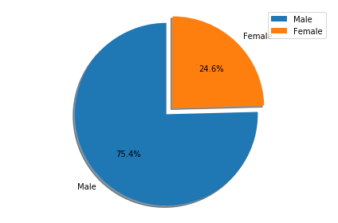

```python
explode=(0.1,0)
fig1,ax1=plt.subplots()
ax1.pie(df['Gender'].value_counts(), explode=explode,labels=['Male','Female'], autopct='%1.1f%%',shadow=True, startangle=90)
ax1.axis('equal')
plt.tight_layout()
plt.legend()
plt.show()
```

上图，男人的购买数量远高于女人

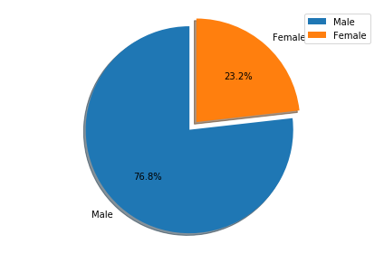

```python
df1=df[['Gender','Purchase']].groupby('Gender').sum().sort_values(by='Purchase',ascending=False)
explode=(0.1,0)
fig1,ax1=plt.subplots()
ax1.pie(df1['Purchase'], explode=explode,labels=['Male','Female'], autopct='%1.1f%%',shadow=True, startangle=90)
ax1.axis('equal')
plt.tight_layout()
plt.legend()
plt.show()
```

在购买金额上也是男人大于女人

```python
df[['Gender','Purchase']].groupby('Gender').mean().sort_values(by='Purchase',ascending=False)
```

| Gender | Purchase |
| --- | --- |
| M | 9504.771713 |
| F | 8809.761349 |

男人购买物品的平均价格也高

### 再看看age

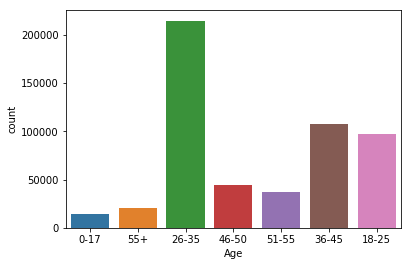

```python
sns.countplot(df['Age'])
```

```python
df.pivot_table(values=['Purchase'],index=['Age'],columns=['Gender'],aggfunc=np.sum)
```

| Gender Age | Purchase F | Purchase M |
| --- | --- | --- |
| 0-17 | 41826615 | 90832391 |
| 18-25 | 202209450 | 699459830 |
| 26-35 | 433857680 | 1565891426 |
| 36-45 | 239010480 | 771639085 |
| 46-50 | 114796993 | 298621230 |
| 51-55 | 87972407 | 273935949 |
| 55+ | 44950396 | 152664446 |

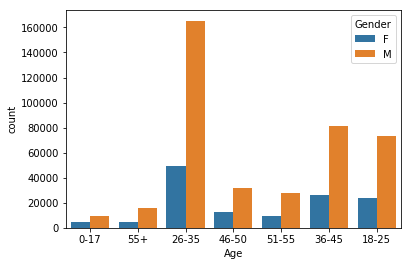

```python
sns.countplot(df['Age'],hue=df['Gender'])
```

[figure not shown]

```python
sns.catplot(x="Age", y="Purchase", hue="Gender", data=df,height=6, kind="bar",estimator=np.sum)
```

以上，26-35是购买主力军，男女皆如此，这个年龄段有钱欲望大，跟是否婚育也可能有关系，下面看一下

```python
df[['Marital_Status','Purchase']].groupby('Marital_Status').sum()
```

| Marital_Status | Purchase |
| --- | --- |
| 0 | 2966289500 |
| 1 | 2051378878 |

总体上看，已婚人士购买力大幅下滑，结了婚生活压力大啊。再加入年龄分类看一下

```python
df.pivot_table(values=['Purchase'],index=['Age'],columns=['Marital_Status'],aggfunc=np.sum)
```

| Marital_Status Age | Purchase 0 | Purchase 1 |
| --- | --- | --- |
| 0-17 | 1.326590e+08 | NaN |
| 18-25 | 7.145688e+08 | 187100468.0 |
| 26-35 | 1.215627e+09 | 784121630.0 |
| 36-45 | 6.154955e+08 | 395154091.0 |
| 46-50 | 1.114215e+08 | 301996686.0 |
| 51-55 | 1.028122e+08 | 259096169.0 |
| 55+ | 7.370501e+07 | 123909834.0 |

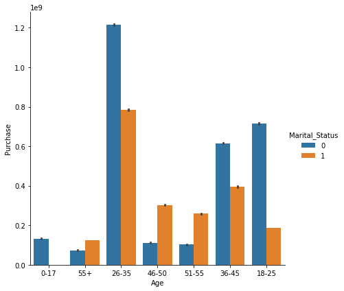

```python
sns.catplot(x="Age", y="Purchase", hue="Marital_Status", data=df,height=6, kind="bar",estimator=np.sum)
```

可以看出，情况有了一些变化，45岁以上出现倒转，已婚反而购买力强，可能是因为45岁以上未婚的人大都混得不好，而45岁以上已婚人孩子大了没有养育压力了，又赚了不少钱，所以购买力上升。加入性别再看看

```python
df.pivot_table(values=['Purchase'],index=['Age','Gender'],columns=['Marital_Status'],aggfunc=np.sum)
```

| Age | Marital_Status Gender | Purchase 0 | Purchase 1 |
| --- | --- | --- | --- |
| 0-17 | F | 41826615.0 | NaN |
|  | M | 90832391.0 | NaN |
| 18-25 | F | 153305178.0 | 48904272.0 |
|  | M | 561263634.0 | 138196196.0 |
| 26-35 | F | 254464648.0 | 179393032.0 |
|  | M | 961162828.0 | 604728598.0 |
| 36-45 | F | 148392364.0 | 90618116.0 |
|  | M | 467103110.0 | 304535975.0 |
| 46-50 | F | 27113309.0 | 87683684.0 |
|  | M | 84308228.0 | 214313002.0 |
| 51-55 | F | 32195400.0 | 55777007.0 |
|  | M | 70616787.0 | 203319162.0 |
| 55+ | F | 16518203.0 | 28432193.0 |
|  | M | 57186805.0 | 95477641.0 |

仍然如此。此处如果绘图的话需要融合字段，将Marital_Statuse和gender合为一个具有四个类别的新字段，然后如上绘图。 题外话：现在有很多关于结婚优劣的讨论，从这里的购买力能够推论出，结婚的话，中年时期可能过的艰难一点，但中老年以后反而更轻松，不结婚正相反，从这个数据推出这个结论有点意外之喜，当然这只是出于好玩的推论

### 关于occupation职业这个字段的数据意义没看太懂，数据源也没有说明，每种类别到底是什么含义，暂且放一放，City_Category城市的分类也不明白意义，似乎没办法用于交叉对比，只看一下是否与购买力有关吧，之后预测建模可能有用。

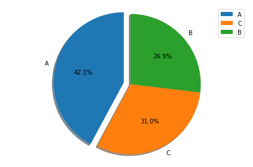

```python
explode = (0.1, 0, 0)
fig1, ax1 = plt.subplots()
ax1.pie(df['City_Category'].value_counts(),explode=explode, labels=df['City_Category'].unique(), autopct='%1.1f%%',
        shadow=True, startangle=90)
# Equal aspect ratio ensures that pie is drawn as a circle
ax1.axis('equal')
plt.tight_layout()
plt.legend()
plt.show()
```

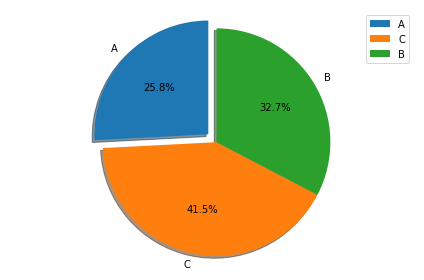

```python
explode = (0.1, 0, 0)
fig1, ax1 = plt.subplots()
ax1.pie(df[['Purchase','City_Category']].groupby('City_Category').sum(),explode=explode, labels=df['City_Category'].unique(), autopct='%1.1f%%',
        shadow=True, startangle=90)
ax1.axis('equal')
plt.tight_layout()
plt.legend()
plt.show()
```

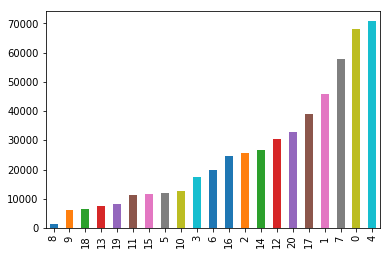

```python
fig1, ax1 = plt.subplots()
df['Occupation'].value_counts().sort_values().plot('bar')
```

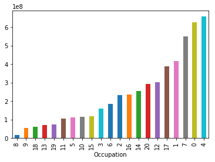

```python
fig1, ax1 = plt.subplots()
df2=df.groupby('Occupation')['Purchase'].sum().sort_values()#这种写法返回series，上面的另一种写法返回dt
df2.plot('bar')
```

职业有相关

看一下停留时间

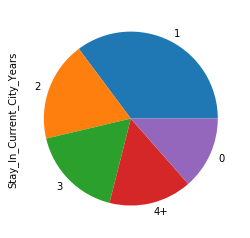

```python
df['Stay_In_Current_City_Years'].value_counts().plot('pie')
```

停留一年的人最多

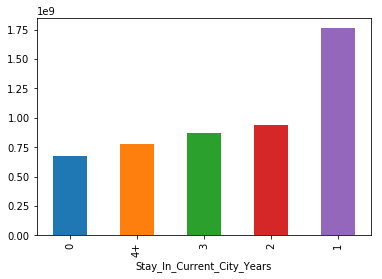

```python
fig1, ax1 = plt.subplots()
df.groupby('Stay_In_Current_City_Years')['Purchase'].sum().sort_values().plot('bar')
```

停留一年的人购买力也最强

再看看哪种产品卖的最好

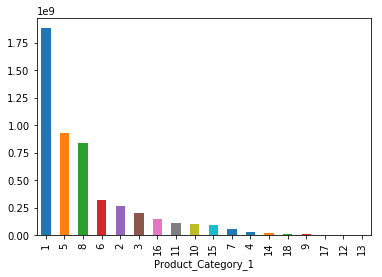

```python
df.groupby('Product_Category_1')['Purchase'].sum().sort_values(ascending=False).plot('bar')
```

分类为1的产品卖的最好

```python
df[['User_ID','Purchase']].groupby('User_ID').sum().sort_values(by='Purchase',ascending=False).head(5)
```

| User_ID | Purchase |
| --- | --- |
| 1004277 | 10536783 |
| 1001680 | 8699232 |
| 1002909 | 7577505 |
| 1001941 | 6817493 |
| 1000424 | 6573609 |

用户1004277的购买力遥遥领先，妥妥的优质客户，抓紧了

```python
df['User_ID'].value_counts()[:10]
```

```
1001680    1025
1004277     978
1001941     898
1001181     861
1000889     822
1003618     766
1001150     752
1001015     739
1002909     717
1001449     714
Name: User_ID, dtype: int64
```

104277用户购买数量也是非常高的！

```python
df[['Product_ID','Purchase']].groupby('Product_ID').sum().sort_values(by='Purchase',ascending=False).head(10)
```

| Product_ID | Purchase |
| --- | --- |
| P00025442 | 27532426 |
| P00110742 | 26382569 |
| P00255842 | 24652442 |
| P00184942 | 24060871 |
| P00059442 | 23948299 |
| P00112142 | 23882624 |
| P00110942 | 23232538 |
| P00237542 | 23096487 |
| P00057642 | 22493690 |
| P00010742 | 21865042 |

```python
df['Product_ID'].value_counts()[:10]
```

```
P00265242    1858
P00110742    1591
P00025442    1586
P00112142    1539
P00057642    1430
P00184942    1424
P00046742    1417
P00058042    1396
P00059442    1384
P00145042    1384
Name: Product_ID, dtype: int64
```

```python
df[df['Product_ID']=='P00265242']['Purchase'].sum()#最高销量商品对应销售额
```

```
13983325
```

```python
df[df['Product_ID']=='P00025442']['Product_ID'].value_counts()#最高销售额商品对应销量
```

```
P00025442    1586
Name: Product_ID, dtype: int64
```

上面分别是产品销售额与销量前十，多多进货。另外可以看出，两者并不一致，差异相当大，销量最高的销售额相当低了。

最后做个相关分析

```python
lb = LabelEncoder()
df['Gender'] = lb.fit_transform(df['Gender'])
df['Age'] = lb.fit_transform(df['Age'])
df['City_Category'] = lb.fit_transform(df['City_Category'])
df['Stay_In_Current_City_Years'] = lb.fit_transform(df['Stay_In_Current_City_Years'])
```

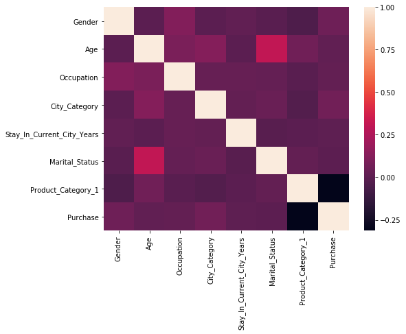

```python
fig,ax = plt.subplots(figsize=(8,6))
sns.heatmap(df.drop(['User_ID','Product_ID'],axis=1).corr())
```

上图可以看出，总体而言没有任何一个变量与购买力强相关的，只能看看组合起来做回归怎么样

回归分析

```python
from sklearn.model_selection import train_test_split
X=df.drop(['User_ID','Product_ID','Purchase'],1)
Y=df['Purchase']
```

```python
X_train, X_test, y_train, y_test=train_test_split(X,Y,test_size=0.2)
```

```python
lm = linear_model.LinearRegression()
models = lm.fit(X_train, y_train)
predictions = lm.predict(X_test)
```

```python
models.score(X_test,y_test)#评估模型
```

```
0.10549724289209716
```

有点低

```python
scores = cross_val_score(models, X, Y, cv=6)
scores
```

```
array([0.10650461, 0.10634936, 0.104444  , 0.10415496, 0.10269916,
       0.10792395])
```

回归模型的预测能力还是比较低的，以后再看看其它模型或对模型进行调整，或者对特征进行深入调整

### 在用户购买力预测方面，使用了线性回归模型，由模型评分可知，预测力比较低，还需进一步优化

# 至此，两个数据分析目标已完成